# The path to college education: The role of math and verbal skills

Journal of Political Economy, vol. 129, no. 10, Septemver 2021: 2905-2946

by Esteban Aucejo, Jonathan James

2022年06月14日 12:37

# Summary

- Previous studies have used English and math exam scores directly. Measurement errors and multicollinearity undermined the research.
- A factor model (Cunha, Heckman, and Schennach 2010) is used to extract math and verbal skills and to reduce measurement errors and multicollinearity.

  Cunha, Flavio, James J. Heckman, and Susanne M. Schennach. 2010. “Estimating the Technology of Cognitive and Noncognitive Skill Formation.” *Econometrica* 78 (3): 883–931. https://doi.org/10.3982/ECTA6551.
- Massive data of .5 million students with 30 subject exams from UK are used.

  Math on lagged math (elasticities .64-1.28), lagged verbal (0-.11). Verbal on lagged verbal (.80-1.06).
- Math skills only contribute to future math skills. Verbal skills contrubute to both future verbal and math skills.

  College enrollment returns by verbal vs. math skills: .150 vs. .057 for females, .127 vs. .061 for males.
- Marginal returns to college enrollment on verbal skills are larger than math skills (2-3 times).
- This happens all the students except for top 20% of males who show similar marginal returns on both skills.
- Improving school quality to “outstanding” grade can increase college enrollment rate by 4.5% points.
- Policy should aim: Verbal skills and school quality improvement.
- Females have higher verbal skills than males. This can explain the college enrollment gender gaps in many countries.
- Previous studies used English exam scores with school achievement. Major part of verbal skills was subsumed in school achiervement and resulted in near zero estimates on verbal skills.
- Two-stage estimation procedure is developed to maximise a complex nonlinear likelihood.

# Intro

## Previous research

**Cognitive vs. noncognitive**  
Cameron and Heckman (2001); Cawley, Heckman, and Vytlacil (2001); Heckman, Stixrud, and Urzua (2006)  
Hard to put them in policy. Math-verbal dimension is easier to understand how formal school education contributes.

Cameron, Stephen V., and James J. Heckman. 2001. “The Dynamics of Educational Attainment for Black, Hispanic, and White Males.” *Journal of Political Economy* 109 (3): 455–99.

Cawley, John, James J. Heckman, and Edward Vytlacil. 2001. “Three Observations on Wages and Measured Cognitive Ability.” *Labour Economics* 8 (4): 419–42.

Heckman, James J., Jora Stixrud, and Sergio Urzua. 2006. “The Effects of Cognitive and Noncognitive Abilities on Labor Market Outcomes and Social Behavior.” *Journal of Labor Economics* 24 (3): 411–82.

**Nested CES production function estimation**  
Theories (Acemoglu and Autor 2011; Acemoglu and Restrepo 2022) and macroeconometrics (Pandey 2008) use them often but not in microeconometrics.

Acemoglu, Daron, and David Autor. 2011. “Skills, Tasks and Technologies: Implications for Employment and Earnings.” *Handbook of Labor Economics* 4: 1043–1171.

Acemoglu, Daron, and Pascual Restrepo. 2022. “Demographics and Automation.” *The Review of Economic Studies* 89 (1): 1–44. https://doi.org/10.1093/restud/rdab031.

Pandey, Manish. 2008. “Human Capital Aggregation and Relative Wages Across Countries.” *Journal of Macroeconomics* 30 (4): 1587–1601. https://doi.org/https://doi.org/10.1016/j.jmacro.2008.06.001.

**Dynamic factor models**  
A two-step estimation procedure. Similar to Attanasio, Meghir, and Nix (2020) but CRS assumption is relaxed, nonparametric estimation of individual specific factor distributions, etc.

Attanasio, Orazio, Costas Meghir, and Emily Nix. 2020. “Human Capital Development and Parental Investment in India.” *The Review of Economic Studies* 87 (6): 2511–41.

**Gender gaps in college enrollment**  
Not explained previously.

**Priority in policies: Math**  
Math is associated with future labour market successes (Levine and Zimmerman 1995; Rose and Betts 2004; Joensen and Nielsen 2009). The results of the paper are at odds with these. Also, a caution is raised if one wants to control for school achievements in retuns-to-school regressions.

Levine, Phillip B., and David J. Zimmerman. 1995. “The Benefit of Additional High-School Math and Science Classes for Young Men and Women.” *Journal of Business & Economic Statistics* 13 (2): 137–49.

Rose, Heather, and Julian R. Betts. 2004. “The Effect of High School Courses on Earnings.” *Review of Economics and Statistics* 86 (2): 497–513.

Joensen, Juanna Schrøter, and Helena Skyt Nielsen. 2009. “Is There a Causal Effect of High School Math on Labor Market Outcomes?” *Journal of Human Resources* 44 (1): 171–98.

## Biases in OLS estimators using error-ridden correlated variables

Errors in variables are
$$X_{1}=x_{1}+u_{1}, \quad X_{2}=x_{2}+u_{2},\quad \mbox{cov}[x_{1}, x_{2}]\neq 0, \quad u_{1}\perp u_{2},$$
where we only observe $X$ but not true $x$ in
$$Y_{i}=\beta_{0}+\beta_{1}X_{1i}+\beta_{2}X_{2i}+u_{i}.$$

- One can show OLS estimates give $\hat{\beta}_{1}\simeq \hat{\beta}_{2}$ no matter true values of $\beta_{1}, \beta_{2}$, when correlation of two covariates becomes 1 and signal-to-noise ratios are similar.
- Authors write that factor models can clean up measurement errors and correlations. By design, factors are modeled as orthogonal given unobserved individual random effects, and factors are estimated, so when they are estimated imprecisely, it manifests the problem with large standard errors, which is not the case in EIV-OLS.

Denote $\lambda_{j}=\frac{\mbox{$\mathcal V$}[u_{j}]}{\mbox{$\mathcal V$}[X_{j}]}=\frac{\mbox{$\mathcal V$}[u_{j}]}{\mbox{$\mathcal V$}[x_{j}]+\mbox{$\mathcal V$}[u_{j}]}$ for $j=1,2$. Madala (1992), 11.9 gives formulae for EIV-OLS estimators in the two variable case:
$$\begin{equation}
\begin{aligned}
\text{plim}\ \hat{\beta}_{1}
&=
\beta_{1}-\frac{\lambda_{1}\beta_{1}-\rho\lambda_{2}\beta_{2}}{1-\rho^{2}},\\
\text{plim}\ \hat{\beta}_{2}
&=
\beta_{2}-\frac{\lambda_{2}\beta_{2}-\rho\lambda_{1}\beta_{1}}{1-\rho^{2}}.
\end{aligned}
\tag{11.9}
\end{equation}$$
We see that
$$\lambda_{j}\left(\mbox{$\mathcal V$}[x_{j}]+\mbox{$\mathcal V$}[u_{j}]\right)=\mbox{$\mathcal V$}[u_{j}]
\quad \Leftrightarrow\quad\frac{\mbox{$\mathcal V$}[u_{j}]}{\mbox{$\mathcal V$}[x_{j}]}=\frac{\lambda_{j}}{1-\lambda_{j}},$$
so
$$\mbox{$\mathcal V$}[x_{j}]+\mbox{$\mathcal V$}[u_{j}]=\mbox{$\mathcal V$}[x_{j}]\left(1+\frac{\lambda_{j}}{1-\lambda_{j}}\right)=\mbox{$\mathcal V$}[x_{j}]\frac{1}{1-\lambda_{j}}.$$
By assumption $\mbox{cov}[X_{1}, X_{2}]=\mbox{cov}[x_{1}+x_{2}]$, the correlation is
$$\begin{aligned}
\frac{\mbox{cov}[X_{1}, X_{2}]}{\left\{\mbox{$\mathcal V$}_{X_{1}}\mbox{$\mathcal V$}_{X_{2}}\right\}^{\frac{1}{2}}}
&=
\frac{\mbox{cov}[x_{1}+x_{2}]}{\left\{\left(\mbox{$\mathcal V$}_{x_{1}}+\mbox{$\mathcal V$}_{u_{1}}\right)\left(\mbox{$\mathcal V$}_{x_{2}}+\mbox{$\mathcal V$}_{u_{2}}\right)\right\}^{\frac{1}{2}}}
=
\frac{\mbox{cov}[x_{1}+x_{2}]}{\left\{\mbox{$\mathcal V$}_{x_{1}}\left(1-\lambda_{1}\right)^{-1}\mbox{$\mathcal V$}_{x_{2}}\left(1-\lambda_{2}\right)^{-1}\right\}^{\frac{1}{2}}},\\
\rho
&=
\rho^{*}\sqrt{\left(1-\lambda_{1}\right)\left(1-\lambda_{2}\right)}.
\end{aligned}$$
where $\rho^{*}=\mbox{corr}[x_{1}, x_{2}]$.

Madala, G. S. 1992. *Introduction to Econometrics*. 2nd ed. McMillan.

Setting $\lambda_{1}=\lambda_{2}=\lambda$, plug these and take limits $\rho^{*}\rightarrow 1$:
$$\begin{aligned}
\frac{\text{plim}\ \hat{\beta}_{1}}{\text{plim}\ \hat{\beta}_{2}}
&=
\frac{\{1-\rho^{*2}(1-\lambda)^{2}\}\beta_{1}-\lambda\{\beta_{1}-\rho^{*}(1-\lambda)\beta_{2}\}}{\{1-\rho^{*2}(1-\lambda)^{2}\}\beta_{2}-\lambda\{\beta_{2}-\rho^{*}(1-\lambda)\beta_{1}\}},\\
\lim_{\rho^{*}\rightarrow 1} \frac{\text{plim}\ \hat{\beta}_{1}}{\text{plim}\ \hat{\beta}_{2}}
&=
\frac{\lambda^{2}\beta_{1}-\lambda\{\beta_{1}-(1-\lambda)\beta_{2}\}}{\lambda^{2}\beta_{2}-\lambda\{\beta_{2}-(1-\lambda)\beta_{1}\}},\\
&=
\frac{\lambda(1-\lambda)\left(\beta_{2}-\beta_{1}\right)}{\lambda(1-\lambda)\left(\beta_{1}-\beta_{2}\right)},\\
&=-1.
\end{aligned}$$

Authors show it goes to 1, not -1. Not sure where I got it wrong.

## English school system

| age | stages |
| --- | --- |
| 4 | Foundation |
| 5-6 | KS1 |
| 7-11 | KS2 |
| 12-14 | KS3 |
| 15-16 | KS4 (compulsory ends) |
| 17-18 | A-levels (3-4 subjects) |
| 19-21 | Bachelor’s |

# Data

Panel data of 500K students completing compulsory education in 2006-07. Private school students (6.5%) are not included.

**National Pupil Database**  
*Higher Education Statistics Agency*

**Pupil Level Annual School Census/School Census**  
*Higher Education Statistics Agency*

- Among all exam scores, math and English are compulsory in all 4 key stages up to KS4.
- Variables: Student demographics, neighborhood deprivation, school names, exam scores, teacher assessments, school absences, postsecondary education outcomes.
- This rich set of data allows estimation of factors.

# Model

## Production function

Skill $\Theta^{k}_{it}$ production function of subject $k\in\{m, v\}$ at $t=\{2, 3, 4\}$
$$\begin{aligned}
\Theta^{k}_{it}
&=
A^{k}_{it}\left[\delta^{k}_{t}\left(\Omega^{k}_{it}\right)^{\rho^{k}_{t}}+(1-\delta^{k}_{t})\left(Q_{it}\right)^{\rho^{k}_{t}}\right]^{\frac{r^{k}_{t}}{\rho^{k}_{t}}},\\
&=
A^{k}_{it}\bigg[\delta^{k}_{t}\left\{\alpha^{k}_{t}\left(\Theta^{m}_{it-1}\right)^{\gamma^{k}_{t}}+(1-\alpha^{k}_{t})\left(\Theta^{v}_{it-1}\right)^{\gamma^{k}_{t}}\right\}^{\frac{\rho^{k}_{t}}{\gamma^{k}_{t}}}+(1-\delta^{k}_{t})\left(Q_{it}\right)^{\rho^{k}_{t}}\bigg]^{\frac{r^{k}_{t}}{\rho^{k}_{t}}}.
\end{aligned}$$
Denote $\ln\Theta^{k}_{it}=\theta^{k}_{it}$.

- Skill aggregator $\Omega^{k}_{it}$ (can be thought as non-TFP general skill level) nests another level of CES aggregation. By doing so, elasticities of substitution can vary across inputs by periods.

TFP
$$A^{k}_{it}=e^{\psi^{k}_{t}x_{it}+\pi^{k}_{i}+\nu^{k}_{it}}, \quad \nu^{k}_{it}\sim N(0, \zeta^{2}_{tk}).$$
$x_{it}$ is a vector of individual observables and neighbourhood FEs, $\pi^{k}_{i}$ is individual skill specific REs, and $\nu^{k}_{it}$ is an idiosyncratic shock to skill production.

## Measurement system

Scores/measures and factors $\theta'_{i} = \left( \begin{array}{ccccc} \theta^{m}_{i1} & \theta^{v}_{i1}& \dots &\theta^{m}_{i4}& \theta^{v}_{i4} \end{array} \right)$ with factor loading $\lambda'_{j}= \left( \begin{array}{ccccc} \lambda^{m}_{1}& \lambda^{v}_{1}& \dots &\lambda^{m}_{4}& \lambda^{v}_{4} \end{array} \right)$:
$$w^{*}_{ij}=\mu_{j}+\lambda'_{j}\theta_{i}+\eta_{ij}, \quad \eta_{ij}\sim \mathcal N(0, \sigma^{2}_{j}), \ \theta_{i}\sim MVN(\xi, \Delta).$$
Factors $\theta$ are assumed to be distributed as multivariate normal.

- Factor loadings of each outcomes are estimated on intercept, concurrent math and/or verbal while other period math/verbal are set to 0. For math/verbal tests, loadings on concurrent math/verbal are set to 1, others to 0 (see Table O4).

Exam self-selection for subject $c$ at key stage 4: Take an exam if $a^{*}_{ic}>0$.
$$a^{*}_{ic}=\tau_{c0}+\tau_{c1}\theta^{m}_{3}+\tau_{c2}\theta^{v}_{3}+\tau_{c4}\theta^{sel}_{i,4}+v_{ic}, \quad v_{ic}\sim\Lambda(0, 1).$$
$\theta^{sel}_{i,4}$ is a factor that affirms intellectual challenges that are common for all subjects. $v_{ic}$ is distributed as logistic with mean zero, scale 1.

# Estimation

## Likelihood and two-step estimation

**First stage:** Estimate measurement system parameters.  
**Second stage:** Estimate CES (production function) parameters.

Log likelihood of $n$ students
$$\begin{equation}
\begin{aligned}
LL(\Psi)
&=\sum_{i=1}^{n}\ln L\left(w_{i}, a_{i}, x_{i}, Q_{i}\right),\\
&=\sum_{i=1}^{n}\ln \int_{\theta}L\left(w_{i}, a_{i}, x_{i}, Q_{i}\left|\theta\right.\right)d\theta,\\
&\propto\sum_{i=1}^{n}\ln \left[\int_{\theta} p\left(w_{i}, a_{i}\left|\theta\right.\right)F\left(\theta\left| x_{i}, Q_{i}\right.\right)d\theta\right], \quad [ F\left(\theta, x_{i}, Q_{i}\right)=F\left(\theta\left| x_{i}, Q_{i}\right.\right) F\left(x_{i}, Q_{i}\right), \ \text{drop }F\left(x_{i}, Q_{i}\right)]\\
&=\sum_{i=1}^{n}\ln \left[\int_{\theta} p\left(w_{i}, a_{i}\left|\theta\right.\right)\frac{p\left(x_{i}, Q_{i}\left|\theta \right.\right)p(\theta)}{p\left(x_{i}, Q_{i}\right)}d\theta\right], \quad
\left[F\left(\theta\left| x_{i}, Q_{i}\right.\right)=\frac{F\left( x_{i}, Q_{i}\left|\theta\right.\right)F(\theta)}{F\left(x_{i}, Q_{i}\right)}\right]
\\
&=\sum_{i=1}^{n}\ln \left[\int_{\theta} \frac{p\left(w_{i}, a_{i}\right)}{p\left(w_{i}, a_{i}\right)}p\left(w_{i}, a_{i}\left|\theta\right.\right)p(\theta)\frac{p\left(x_{i}, Q_{i}\left|\theta \right.\right)}{p\left(x_{i}, Q_{i}\right)}d\theta\right],\\
&=\sum_{i=1}^{n}\ln \left[\int_{\theta} h\left(\theta\left|\right.w_{i}, a_{i}\right)p\left(w_{i}, a_{i}\right)\frac{p\left(x_{i}, Q_{i}\left|\theta \right.\right)}{p\left(x_{i}, Q_{i}\right)}d\theta\right],\\
&=
\underbrace{\sum_{i=1}^{n}\ln \left[\int_{\theta} p\left(w_{i}, a_{i}\left|\theta\right.\right)p(\theta)d\theta\right]}_{\text{first stage for }\theta, \lambda, \tau, \mu, \sigma^{2}}
+\sum_{i=1}^{n}\ln \left[\int_{\theta} p\left(x_{i}, Q_{i}\left|\theta\right.\right)h\left(\theta\left|w_{i}, a_{i}\right.\right)d\theta\right]
- \sum_{i=1}^{n}\ln \left[p\left(x_{i}, Q_{i}\right)\right],\\
\end{aligned}
\tag{4}
\end{equation}$$
Authors maximize the “first stage” part over $\lambda, \tau, \mu, \sigma^{2}$ given simulated $\theta$ while ignoring the rest. They write that ignoring the second term may give rise to inefficiency, but simplifies estimation.
$$\mbox{LL}_{\text{first}\\ \text{stage}}=
\sum_{i=1}^{n}\ln \left[\int_{\theta} p\left(w_{i}, a_{i}\left|\theta\right.\right)p(\theta)d\theta\right]$$
To estimate CES parameters, it is useful to consider the score (gradient of likelihood). MLE is a root of the score. Score is given by:
$$\begin{equation}
\begin{aligned}
\frac{\partial LL(\Psi)}{\partial \Psi}
&=
\sum_{i=1}^{n}\frac{1}{L\left(w_{i}, a_{i}, x_{i}, Q_{i}\right)}\int_{\theta}\frac{\partial p\left(w_{i}, a_{i}\left|\theta\right.\right)F\left(\theta\left| x_{i}, Q_{i}\right.\right)}{\partial \Psi}d\theta,\\
&=
\sum_{i=1}^{n}\int_{\theta}\frac{p\left(w_{i}, a_{i}\left|\theta\right.\right)F\left(\theta\left| x_{i}, Q_{i}\right.\right)}{L\left(w_{i}, a_{i}, x_{i}, Q_{i}\right)}\frac{\partial \ln \left[p\left(w_{i}, a_{i}\left|\theta\right.\right)F\left(\theta\left| x_{i}, Q_{i}\right.\right)\right]}{\partial \Psi}d\theta,\\
&=
\sum_{i=1}^{n}\int_{\theta}h\left(\theta\left|w_{i}, a_{i}, x_{i}, Q_{i}\right.\right)
\frac{\partial \ln \left[p\left(w_{i}, a_{i}\left|\theta\right.\right)F\left(\theta\left| x_{i}, Q_{i}\right.\right)\right]}{\partial \Psi}d\theta,\\
&=
\sum_{i=1}^{n}\int_{\theta}
\frac{\partial \ln \left[p\left(w_{i}, a_{i}\left|\theta\right.\right)\right]}{\partial \Psi}h\left(\theta\left|w_{i}, a_{i}, x_{i}, Q_{i}\right.\right)d\theta
+\underbrace{\sum_{i=1}^{n}\int_{\theta}
\frac{\partial \ln \left[F\left(\theta\left| x_{i}, Q_{i}\right.\right)\right]}{\partial \Psi}h\left(\theta\left|w_{i}, a_{i}, x_{i}, Q_{i}\right.\right)d\theta}_{\text{second stage for }\alpha, \delta, \gamma, \rho, \psi, \pi},\\
\end{aligned}
\end{equation}$$
If one finds the CES roots $\alpha, \delta, \gamma, \rho, \psi, \pi$ of the 2nd term, one can maximise the conditional likelihood (conditional on $\theta$). Note that the first term only involves parameters estimated in the first stage. This naturally suggests the second stage for the CES roots, where authors ignore the dependence of $h$ on $x_{i}, Q_{i}$ for simplicity (they write inclusion did not change results):
$$\mbox{LL}_{\text{second}\\ \text{stage}}=\sum_{i=1}^{n}\int_{\theta}
\ln \left[F\left(\theta\left| x_{i}, Q_{i}\right.\right)\right]h\left(\theta\left|w_{i}, a_{i}\right.\right)d\theta.$$

Authors say maximising over the first term gives unbiased and consistent estimates. Would not the second term be necessay…?

## Implementation

10 draws to reduce simulation errors. This makes this part simulated partial likelihood, I guess. In the first-stage, authors simulate 10 draws of $\theta_{i}$, maximise the mean of likelihood of 10 draws over other first stage paraeters. Let the density of a vector of factors $d=1,\dots, 10$ be written as $K_{d}\left(\theta\left|\xi_{d}, \Delta_{d}\right.\right)$ and $\theta_{id}$ is sampled with probability $\kappa_{d}$. First-stage is given as:
$$\begin{aligned}
\mbox{LL}_{\text{first}\\ \text{stage}}\left(\Psi_{A}\right)
&=
\sum_{i=1}^{n}\ln \left[\int_{\theta} p\left(w_{i}, a_{i}\left|\theta\right.\right)p(\theta)d\theta\right],\\
&=
\sum_{i=1}^{n}\ln \left[\sum_{d=1}^{10}\kappa_{d}\int_{\theta} p\left(w_{i}, a_{i}\left|\theta\right.\right)K_{d}\left(\theta\left|\xi_{d}, \Delta_{d}\right.\right)d\theta\right],\\
&=
\sum_{i=1}^{n}\ln \left[\sum_{d=1}^{10}\kappa_{d}\int_{\theta} \left(\prod_{j=1}^{J}p\left(w_{ij}\left|\theta\right.\right)\prod_{c=1}^{C}p\left(a_{ic}\left|\theta\right.\right)\right)K_{d}\left(\theta\left|\xi_{d}, \Delta_{d}\right.\right)d\theta\right].
\end{aligned}$$
In the EM, one gets updates of parameters $\kappa_{d}, \xi_{d}, \Delta_{d}$ of $K_{d}\left(\theta\left|\xi_{d}, \Delta_{d}\right.\right)$ from $m$ to $m+1$ as one sample $R$ draws from $h\left(\theta\left|w_{i}, a_{i}, \Psi^{(m)}\right.\right)$ with $R=4500$. $\Psi$ is a set of all parameters.
$$\left\{\begin{aligned}
w^{(m)}_{ir}
&=
\frac{L_{cont}\left(w_{i}\left|\theta^{(m)}_{ir}\right.\right)L_{cens}\left(w_{i}\left|\theta^{(m)}_{ir}\right.\right)L_{sel}\left(a_{i}\left|\theta^{(m)}_{ir}\right.\right)}{\sum\limits_{r'=1}^{R}L_{cont}\left(w_{i}\left|\theta^{(m)}_{ir'}\right.\right)L_{cens}\left(w_{i}\left|\theta^{(m)}_{ir'}\right.\right)L_{sel}\left(a_{i}\left|\theta^{(m)}_{ir' }\right.\right)},\\
\hat{\kappa}_{ir}
&=
w^{(m)}_{ir}\frac{\kappa^{(m)}_{d}\Phi\left(\theta^{(m)}_{ir}, \xi^{(m)}_{d}, \Delta^{(m)}_{d}\right)}{\sum\limits_{d'=1}^{10}\kappa^{(m)}_{d}\Phi\left(\theta^{(m)}_{ir}, \xi^{(m)}_{d'}, \Delta^{(m)}_{d'}\right)},\\
\kappa^{(m+1)}_{d}
&=
\frac{1}{n}\sum_{i=1}^{n}\sum_{r=1}^{R}\hat{\kappa}_{ir},\\
\xi^{(m+1)}_{d}
&=
\frac{\sum\limits_{i=1}^{n}\sum\limits_{r=1}^{R}\hat{\kappa}_{ir}\theta^{(m)}_{ir}}{\frac{1}{n}\sum\limits_{i=1}^{n}\sum\limits_{r=1}^{R}\hat{\kappa}_{ir}},\\
\Delta^{(m+1)}_{d}
&=
\frac{\sum\limits_{i=1}^{n}\sum\limits_{r=1}^{R}\hat{\kappa}_{ir}\theta^{(m)}_{ir}\theta^{(m)'}_{ir}}{\frac{1}{n}\sum\limits_{i=1}^{n}\sum\limits_{r=1}^{R}\hat{\kappa}_{ir}}-\xi^{(m+1)}_{d}\xi^{(m+1)'}_{d}.
\end{aligned}
\right.$$
So the distribution of factors $MVN(\theta|\xi, \Delta)$ are estimated.

Last line used the independence assumption between $w_{ij}$ and $a_{ic}$.

EM algorithm is used to maximize the likelihood.

For loadings on continuous measures use WLS on factors, interval censored data part uses Stewart’s closed form, selection part uses the closed form (minorizaton-maximization algorithm) developed by one of the authors.

For the second-stage, noting that the TFP shocks are iid, the joint likelihood of $\theta$ is given as
$$F\left(\theta\left| x_{i}, Q_{i}\right.\right)=\int_{\pi}
f\left(\theta^{v}_{i4}\left|\theta^{m}_{i3}, \theta^{v}_{i3}, x_{i4}, Q_{i4}, \pi\right.\right)\cdots
f\left(\theta^{m}_{i1}\left|x_{i1}, Q_{i1}, \pi\right.\right)p(\pi)d\pi,$$
where $f$ uses the estimated distribution parameters of the first stage. Based on normality assumption of TFP error $\nu^{k}_{it}\sim N(0, \zeta^{2}_{tk})$ conditional on $\pi$, density of $\theta^{k}_{it}$ is given as
$$f\left(\theta^{k}_{it}\left|\theta^{m}_{it-1}, \theta^{v}_{it-1}, x_{it}, Q_{it}, \pi\right.\right)
\propto
\frac{1}{\zeta_{tk}}e^{-\frac{(\theta^{k}_{it}-\hat{\theta}^{k}_{it})}{2\zeta^{2}_{tk}}},$$
with
$$\hat{\theta}^{k}_{it}
=
\left\{
\begin{array}{l}
x_{i1}\psi^{k}_{1}+r^{k}\ln Q_{i1}+\pi^{1}_{i}\\
x_{it}\psi^{k}_{t}+\pi^{k}_{i}
+
\frac{r^{k}_{t}}{\rho^{k}_{t}}\ln
\bigg[\delta^{k}_{t}\left\{\alpha^{k}_{t}\left(e^{\theta^{m}_{it-1}}\right)^{\gamma^{k}_{t}}+(1-\alpha^{k}_{t})\left(e^{\theta^{v}_{it-1}}\right)^{\gamma^{k}_{t}}\right\}^{\frac{\rho^{k}_{t}}{\gamma^{k}_{t}}}+(1-\delta^{k}_{t})\left(Q_{it}\right)^{\rho^{k}_{t}}\bigg] \quad \mbox{for }t=2, 3, 4.
\end{array}
\right.$$

I have no idea how to draw $\pi_{u}$ samples from an unspecified, “latent class” distribution. Why they choose to draw 5 samples for $\pi$ is not explained. Probably simulation error reduction. $\pi$ is assumed to follow a latent class distribution and drawn with probability $\phi_{u}$ with $u=1, \dots, 5$.

- Plugging into the LL, authors note the nonlinearity of the function due to CES part, one needs to draw a sample and evaluate.

  Metropolis-Hastings algorithm can draw samples from any distribution function if one has a function proportional to it.
- To evaluate the function, they sample $\theta_{i}$ with M-H and set 10 draws of $\theta_{ir}$ from $h\left(\theta\left|w_{i}, a_{i}, \Psi_{A}\right.\right)$ for each individual to reduce simulation errors. $\Psi_{A}$ is a set of all parameters with CES parameter part is being maximised over.

Given 10 draws of $\theta$ for each $i$, one maximises the mean of likelihood over $\alpha, \delta, \gamma, \rho, \psi, \pi$:
$$\mbox{LL}_{\text{second}\\ \text{stage}}=
\sum_{i=1}^{n}\frac{1}{10}\sum_{r=1}^{10}\ln \left[\sum_{u=1}^{U}\phi_{u}
f\left(\theta^{v}_{ir,4}\left|\theta^{m}_{ir,3}, \theta^{v}_{ir, 3}, x_{i4}, Q_{i4}, \pi_{u}\right.\right)
\dots
f\left(\theta^{m}_{ir,1}\left|x_{i1}, Q_{i1}, \pi_{u}\right.\right)
\right].$$
Authors write that they use multiple starting points to ensure global maximum

Not much discussions on how one can increase the second-stage likelihood. Given the normality of errors or concavity of partial likelihoods, any straightforward optimsation algorithm works without a problem…?

## Long term outcomes

$$y^{*}_{is}=z'_{i}\omega_{s}+\left[
\begin{array}{ccccc}
\theta^{m}_{i4} & \left(\theta^{m}_{i4}\right)^{2} &
\theta^{v}_{i4} & \left(\theta^{v}_{i4}\right)^{2}
\end{array}
\right]\beta_{s}+\varphi_{s}\left(\pi_{i}\right)+\varepsilon_{is}, \quad \varepsilon_{is}\sim TypeIExtV.$$
$z'_{i}$ are observables.

# Results

## Factors

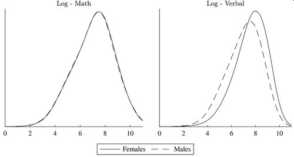

Fig.1: KS4 factor distributions

Summary statistics (Table 2)

- Factors increase with grade, which is expected by design of National Curriculum scores.
- Female-Male differences are small in maths, but are large in verbal and widen with the grade.

Dynamics (Table 3)

- Self-productivity $\frac{\partial \theta^{k}_{it}}{\partial \theta^{k}_{it-1}}$ is large.
- Cross productivity $\frac{\partial \theta^{m}_{it}}{\partial \theta^{v}_{it-1}}$ is nonzero only for verbal but small (8.4% of self-productivity for KS4 females, 2.5% for KS4 males).
- Controlling for time-invariant individual random effects in TFP reduces estimates.
- Improvements in school quality (satisfactory $\rightarrow$ good) increases estimated factors, e.g., increases estimates by 1.082 points of math factor at KS2.

## Other outcomes, gender gaps

College enrollment (Table 4, 6, Figure 2)

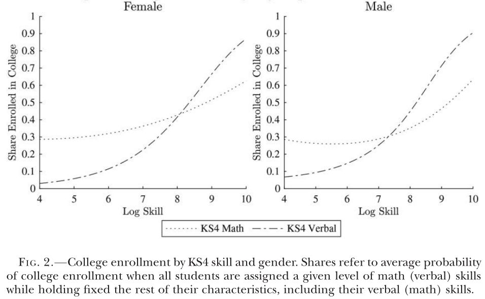

“(G)ender differences in verbal skills play an important role in the gender gaps in college enrollment.”

STEM fields: Gender gaps in skills explained (only) 35% of observed gaps.

- Verbal skills play a larger role than math skills.
- Increasing verbal skills increases college enrollment more than math skills.
- Increasing math skills at low skill levels does not increase college enrollment for males.
- Increasing mean male verbal skills to female level wipes out gender gap in college enrollment (Table 6).
- Increasing school quality (to “outstanding”) increases college enrollment 4.5% points (10.9%) for females and 4.5% points (13.8%) for males (Table 7).

University selection (Table 5)

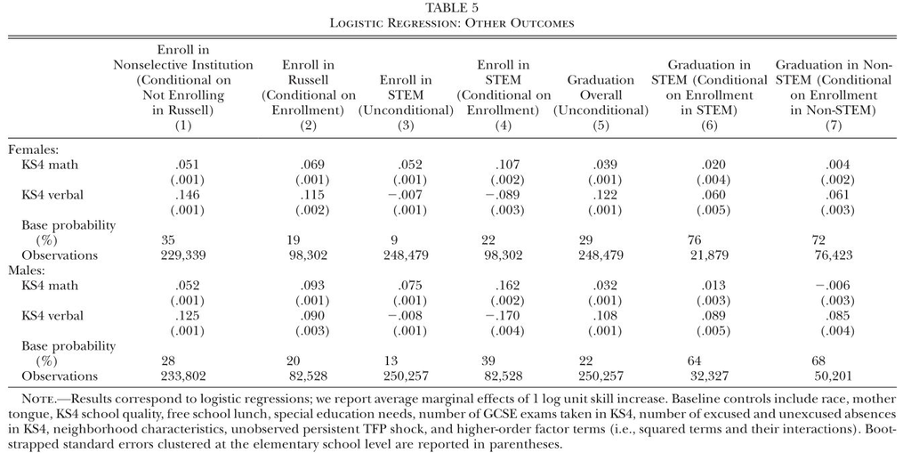

Conditional on STEM enrollment, there are smaller variations in math skills which tend to increase estimated response.

- Verbal skills are more related than math skills in: Nonselective college enrollment, graduation.
- Males math and verbal skill responses are similar for selective college enrollment.
- Nonselective colleges show similar results as in Table 4, implying results are driven by students at the lower tail.

Authors’ interpretations:

Verbal skills $\uparrow$ $\sim$ “psychic costs” of schooling $\downarrow$ $\sim$ years of education $\uparrow$ $\sim$ wage $\uparrow$

Students at the margin of college enrollment are more likely to enroll in non-STEM fields.

Verbal skills increase the graduation probability.

## Results using US sample (as a way to show external validity and wage effects)

**NLSY97**  
*High school trasncripts*: Grades, courses.  
*Armed Services Vocational Aptitude Battery (ASVAB):* 12 subject tests.

### Partial confirmation of verbal skills’ dominance

- Paragraph comprehension is more responsive than arithmetic reasoning in college enrollment. (Table 8, [6])

  Even leaving school achievements not controlled, the estimate on paragraph comprehension is smaller than arithmetic reasoning.
- Adult wage is more responsive to arithmetic reasoning than paragraph comprehension. (Table 9, [2])

This hints that, in the US, verbal skills may be relevant only up to college graduation but not beyond.

### Cautions on wage regressions

“Algebra for all” movement: Why was math given a higher priority? Mincer-style regression: Wages on verbal, math, and school achievement.

- Verbal skills contribute to years of schooling. If we control for school achievements, verbal skills have little, in addition to school achievements, to increase incomes. (Table 9, [3])

# 感想

- Likelihood職人の論文。いろいろなnormalisation (制約)でfactor modelをnatural unitに紐付けている。Measurementとproductionに(ほぼ)加法分離できるようにしている工夫が、複雑な目的関数を最大化するimplementationのポイント。職人技。
- 制約や推計方法にどこまで頑健か、自分には判断つかない。著者が開発したMMアルゴリズムもどれほどすごいのか分からないが、コードを読むとそんなに複雑ではない感じ。
- 数学力より語学力が(大学進学には)大事、という結論は通説を覆すので驚き。でも、よく見ると、驚くには当たらなさそう。

  数学者が「数学や英語とかより日本語をちゃんと学べ」と主張していたが、本論文の結果を考えると、成績トップ以外の集団へのメッセージとして理解してよいのかも。今朝の日経新聞でも、日本語作文力がない子どもを取り上げ、英語の読む書く聞く話すを試験するのに国語では選択式が多い、英語力は日本語力以下なのに、という塾講師の意見が掲載されていた。
- 男女の下位80分位と女子上位20分位で語学力の弾力性が高い。下位80分位はかなり基礎的な論理思考が不足し、それを補うスキル(=語学力アップ)が大学進学に効果を上げているのだろうか。だとすると、頼りない学力レヴェルのことを議論していることになる。

  著者は、女子のSTEM卒業では数学力よりも語学力の方が弾力性が高い、という女子におけるスキル比較しかしていない。数学の弾力性の男女比較をしていない。
- 女子上位20分位でも語学力の弾力性が高い[Table 5 (2)]のは、女子がSTEMに行く(=数学力が問われる進学をする)比率が低いからか? STEM入学を所与としたTable 5 (6)では、STEM卒業への数学力の貢献は女子の方が高く、語学力の貢献は女子の方が低い。大学(全学部)入学とは逆の結果。